# Case study 2: annotation-oriented clustering

# Main finding

在这份数据和当前需求下，**继续优先使用 hclust，TM80 可作为 annotation 的 候选折中阈值**。补测 TM80 后得到 2,383 个 bins，包含 752 个多成员 clusters 及 1,631 个 singletons；相对 5,245 条原始蛋白，聚合后特征数减少 54.6%。 蛋白没有被删除。KO purity 为 89.9%，原表 Detailed Function purity 为 96.7%， Broad Function purity 为 98.6%。这些分数对应不同覆盖范围的标签，不能直接当作 同一测试集上的准确率比较。

原表的 Broad Function 在 TM70 已有 98.5% purity，支持“大方向通常一致”的 观察；提高到 TM80 主要改善较细功能标签的一致性。提高结构阈值可以减少混合， 但不能保证每个 cluster 功能完全相同：TM80 仍有 13 个可评分 cluster 含不同 Broad Function，TM95 也有 2 个。因此按 annotation 所需的功能粒度选择阈值， 对少数有疑义的 cluster 单独审核，比仅按 KO 编号差异评判整个方法更合适。 现有 biomarker/DA 的 hclust 默认值保持不变。

MCL edge≥0.9、I=4 相比 TM90 的同 KO pair recall 较高（56.1% 对 45.8%）， 但其纯度、碎片化和额外参数没有显示足够优势来替换当前 hclust 主流程。 MCL/DBSCAN/HDBSCAN 的探索结果及跨 TM70 兄弟 bin 重组例子保留在后文。

## TM80 check and functional granularity

| TM | bins | multi_clusters | singletons | feature_reduction_pct | KO_purity_pct | detailed_purity_pct | broad_purity_pct |
| --- | --- | --- | --- | --- | --- | --- | --- |
| 50 | 572 | 504 | 68 | 89.1 | 63.2 | 87.3 | 96.4 |
| 70 | 1610 | 809 | 801 | 69.3 | 81.7 | 93.8 | 98.5 |
| 80 | 2383 | 752 | 1631 | 54.6 | 89.9 | 96.7 | 98.6 |
| 90 | 3248 | 620 | 2628 | 38.1 | 96.8 | 98.8 | 99.4 |
| 95 | 3809 | 505 | 3304 | 27.4 | 98.2 | 99.7 | 99.8 |

这里直接使用原 workbook 的功能分类，按相同文本标签评分，不重新推断 KO 之间的距离。排除 3 条标为 `bad results` 的质控记录后，Broad Function 覆盖 1,351 条蛋白，Detailed Function 覆盖 1,336 条；未标注成员仍在聚类中。 较宽的标签本来就更容易一致，且这些标签只覆盖约四分之一的蛋白，不能据此 认定全部成员都具有同一精细分子功能。下表列出可评分范围和实际混合组数。

| reference | min_sim | annotated_proteins | evaluable_bins | mixed_bins | annotation_coverage |
| --- | --- | --- | --- | --- | --- |
| broad_function | 0.50 | 1351 | 103 | 21 | 0.963 |
| broad_function | 0.70 | 1351 | 145 | 13 | 0.930 |
| broad_function | 0.80 | 1351 | 159 | 13 | 0.880 |
| broad_function | 0.90 | 1351 | 156 | 5 | 0.760 |
| broad_function | 0.95 | 1351 | 166 | 2 | 0.648 |
| detailed_function | 0.50 | 1336 | 101 | 32 | 0.965 |
| detailed_function | 0.70 | 1336 | 143 | 20 | 0.931 |
| detailed_function | 0.80 | 1336 | 156 | 20 | 0.881 |
| detailed_function | 0.90 | 1336 | 153 | 10 | 0.760 |
| detailed_function | 0.95 | 1336 | 164 | 3 | 0.649 |

## DBSCAN 90 and HDBSCAN

此前 17 组中已经包含 DBSCAN* 90（`min_pts=3、5`）及 HDBSCAN （`min_pts=3、5、10`），但总结没有单独列出。现补充标准 DBSCAN 90， `border_points=TRUE`、`min_pts=3、5`，再补测 hclust TM80，总计 20 组；沿用相同的 5,245 条蛋白、 距离和 annotation 参考。星号表示边界点作为 noise；无星号表示保留边界点。 HDBSCAN 没有单一 TM90 cutoff，按不同 `min_pts` 比较。

| setting | purity | pair_precision | pair_recall | grouped_fraction | noise_fraction |
| --- | --- | --- | --- | --- | --- |
| DBSCAN* TM90, min_pts=3 | 0.831 | 0.573 | 0.719 | 0.422 | 0.575 |
| DBSCAN* TM90, min_pts=5 | 0.813 | 0.580 | 0.661 | 0.336 | 0.663 |
| HDBSCAN min_pts=3 | 0.882 | 0.912 | 0.461 | 0.591 | 0.409 |
| HDBSCAN min_pts=5 | 0.865 | 0.926 | 0.571 | 0.492 | 0.508 |
| HDBSCAN min_pts=10 | 0.754 | 0.758 | 0.645 | 0.408 | 0.592 |
| DBSCAN TM90, min_pts=3 | 0.831 | 0.577 | 0.743 | 0.446 | 0.554 |
| DBSCAN TM90, min_pts=5 | 0.807 | 0.574 | 0.723 | 0.372 | 0.628 |

# Scope and input audit

本报告比较用户提供的海洋塑料底物 metaproteome 中的聚类结果。所有方法使用 同一组 **5245 条蛋白**及其已缓存 TM-Vec embeddings； annotation 只用于评分，没有参与距离、参数拟合或 cluster 拆分。 原 hclust 方法继续保留，本次不重新拟合 differential abundance 模型。

CSV 提供 31277 条蛋白的 mean PUP；其中 31260 条有 FASTA。Excel 的第二列 Protein ID 唯一，且 逐行蛋白长度与 FASTA 相符。第一列有 3 行不同， 已保留审计表；没有使用第一列覆盖正确的 ID。

| excel_row | first_id | protein | genome | MantisName |
| --- | --- | --- | --- | --- |
| 2247 | 24-1FND7_k141_1177165_3 | 8-2DC2_k141_159026_1 | 8-2DC2.bin.unbinned.fa | arginine kinase |
| 27691 | 7-2DC1_k141_114715_1 | 24-1FND7_k141_741788_3 | 24-1FND7.bin.unbinned.fa | NA |
| 29549 | Porin Omp2b 24% + Interpro Dcap Outermembrane protein IPR045748 (EA) | 8-2DC2_k141_333225_30 | 9-2DC3.bin.85.fa,7-2DC1.bin.12.fa,8-2DC2.bin.66.fa | porin activity |

为对应旧流程，按 CSV 顺序排列蛋白，将 mean PUP 四舍五入，排除 PLA，使用 seed 1、无放回 rarefaction 到深度 655，再移除 >3,000 aa 的 13 条蛋白。原始 mean PUP 另存于 `mean_pup.rds`， 这些四舍五入后的值不是恢复出的原始 spectral counts。

在保留下来的蛋白中，6 条没有缓存 embedding， 占过滤长蛋白后 rarefied abundance 的 0.073%，故在 所有方法中一致排除，另存于 `proteins_without_embeddings.csv`。 旧 HTML 报告是 5,250 条蛋白；当前文件重建的集合及行顺序不能精确复现旧对象。 因此本报告的 TM70 bin 编号只适用于本次 membership，不能直接套用旧编号。

# Annotation references

KO 是 KEGG 为功能正交组定义的类别标识；K 编号本身不是距离。 本报告的“KO 一致性”是**完全相同的 KO 标签**，未计算两个不同 KO 是否 属于相近通路或功能层级。同 KO 是这里的参考分组，不等于已通过实验确认 每条蛋白的功能完全一致。[KEGG 官方说明](https://www.kegg.jp/kegg/ko.html)

主要参考为 **consensus KO**：Mantis、Microbe、EggNOG 中至少两种来源给出 同一个单一 KO，且其他给出单一 KO 的来源没有异议。多 KO、空白和未识别项 不强制取第一个。它是现有 annotation pipelines 的一致意见，不是独立金标准。 当前有 2033 条蛋白可用此标签评分； 1015 条存在来源间单一 KO 冲突，另有完整列表。 未知和冲突蛋白仍参与聚类，但不会以 NA 作为共同功能标签贡献 purity。

| reference | annotated_proteins | fraction |
| --- | --- | --- |
| consensus_KO | 2033 | 0.388 |
| MantisKO | 3455 | 0.659 |
| MicrobeKO | 2607 | 0.497 |
| EggNOG_KO | 2660 | 0.507 |
| curated_name | 1367 | 0.261 |

Purity 按蛋白加权，**只评估至少两个已知标签的 bin**；单蛋白或只有一个 已知标签的 bin 不会得到“完美一致”的评分。Pair precision 是同 bin 已标注 蛋白对中标签一致的比例，pair recall 是同标签蛋白对中仍被放在一起的比例。 Annotation coverage 是落在可评分 bin 中的已标注蛋白比例；grouped fraction 是全部蛋白中处于多成员 bin 的比例。Noise 都保留为独立 singleton，没有合并 成一个组。低混合 bin 数必须与覆盖率一起看。

例如，一个有 10 条已知注释的 cluster 中，8 条为 KO A、2 条为 KO B， 其 purity 是 80%，但它仍是混合 cluster。Pair precision 则是 `(choose(8, 2) + choose(2, 2)) / choose(10, 2) = 64.4%`。 报告总 purity 是对可评分 cluster 的多数标签数求和，再除以其已标注蛋白总数， 不是“完全纯净 cluster 的比例”。若把每条蛋白拆成 singleton，本实现会给 purity 记 NA；同 KO 蛋白对的 recall 会降至 0，因此不能只优化 purity。

# Cluster counts and fragmentation

下面三个数量的含义不同：`assigned_bins` 是算法识别的 clusters（不含 noise， 但包含算法自身产生的 singleton）；`bins` 是返回的最终分箱数，包含被逐条保留 为 singleton 的 noise；`multi_bins` 只计至少两条蛋白的 cluster。 `singleton_bins` 包括普通 singleton 和 noise；`noise_proteins` 是其中的 noise 蛋白数，不是一个合并的 noise cluster。

| setting | assigned_bins | bins | multi_bins | singleton_bins | noise_proteins | median_multi_size | largest_bin |
| --- | --- | --- | --- | --- | --- | --- | --- |
| hclust TM50 | 572 | 572 | 504 | 68 | 0 | 5 | 261 |
| hclust TM70 | 1610 | 1610 | 809 | 801 | 0 | 3 | 101 |
| hclust TM80 | 2383 | 2383 | 752 | 1631 | 0 | 3 | 101 |
| hclust TM90 | 3248 | 3248 | 620 | 2628 | 0 | 2 | 99 |
| hclust TM95 | 3809 | 3809 | 505 | 3304 | 0 | 2 | 96 |
| MCL edge≥0.5, I=2 | 93 | 93 | 85 | 8 | 0 | 8 | 2527 |
| MCL edge≥0.7, I=2 | 957 | 957 | 415 | 542 | 0 | 3 | 433 |
| MCL edge≥0.9, I=2 | 2965 | 2965 | 485 | 2480 | 0 | 3 | 100 |
| MCL edge≥0.5, I=4 | 180 | 180 | 145 | 35 | 0 | 4 | 2161 |
| MCL edge≥0.7, I=4 | 1195 | 1195 | 563 | 632 | 0 | 3 | 341 |
| MCL edge≥0.9, I=4 | 3041 | 3041 | 538 | 2503 | 0 | 3 | 100 |
| DBSCAN* TM70, min_pts=3 | 130 | 1001 | 124 | 877 | 871 | 5 | 3051 |
| DBSCAN* TM90, min_pts=3 | 207 | 3223 | 189 | 3034 | 3016 | 5 | 236 |
| DBSCAN* TM70, min_pts=5 | 68 | 1427 | 63 | 1364 | 1359 | 7 | 2843 |
| DBSCAN* TM90, min_pts=5 | 101 | 3579 | 97 | 3482 | 3478 | 7 | 218 |
| HDBSCAN min_pts=3 | 460 | 2606 | 460 | 2146 | 2146 | 5 | 109 |
| HDBSCAN min_pts=5 | 207 | 2873 | 207 | 2666 | 2666 | 8 | 104 |
| HDBSCAN min_pts=10 | 79 | 3186 | 79 | 3107 | 3107 | 19 | 124 |
| DBSCAN TM90, min_pts=3 | 207 | 3115 | 207 | 2908 | 2908 | 5 | 241 |
| DBSCAN TM90, min_pts=5 | 101 | 3397 | 101 | 3296 | 3296 | 8 | 241 |

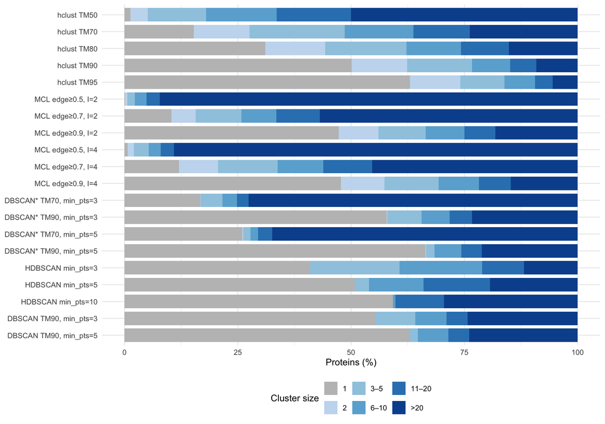

这里的柱形按**蛋白数**加权，而不是只计 cluster 个数：灰色越多，落单蛋白越多； 深色过于集中则可能是大 cluster 合并过度。多成员 cluster 中位大小和最大大小也 保留在表中。当前 MCL（edge≥0.9、I=4）比 TM90 hclust 稍少碎片，但相对 TM70 仍明显更碎；HDBSCAN 增大 `min_pts` 会保留较大的密集组，同时将更多蛋白标为 noise。因此评价 annotation 时，应同时看 KO 一致性、同 KO pair recall、 singleton/noise 比例及 cluster 大小分布。

# Comparison on consensus KO

| setting | bins | purity | pair_precision | pair_recall | grouped_fraction | annotation_coverage | mixed_bins | noise_fraction |
| --- | --- | --- | --- | --- | --- | --- | --- | --- |
| hclust TM50 | 572 | 0.632 | 0.489 | 0.859 | 0.987 | 0.939 | 179 | 0.000 |
| hclust TM70 | 1610 | 0.817 | 0.725 | 0.613 | 0.847 | 0.818 | 124 | 0.000 |
| hclust TM80 | 2383 | 0.899 | 0.895 | 0.540 | 0.689 | 0.724 | 79 | 0.000 |
| hclust TM90 | 3248 | 0.968 | 0.980 | 0.458 | 0.499 | 0.591 | 31 | 0.000 |
| hclust TM95 | 3809 | 0.982 | 0.987 | 0.355 | 0.370 | 0.497 | 14 | 0.000 |
| MCL edge≥0.5, I=2 | 93 | 0.314 | 0.055 | 0.919 | 0.998 | 0.992 | 55 | 0.000 |
| MCL edge≥0.7, I=2 | 957 | 0.621 | 0.303 | 0.900 | 0.897 | 0.872 | 99 | 0.000 |
| MCL edge≥0.9, I=2 | 2965 | 0.916 | 0.852 | 0.581 | 0.527 | 0.630 | 41 | 0.000 |
| MCL edge≥0.5, I=4 | 180 | 0.378 | 0.086 | 0.909 | 0.993 | 0.979 | 72 | 0.000 |
| MCL edge≥0.7, I=4 | 1195 | 0.689 | 0.405 | 0.879 | 0.880 | 0.853 | 117 | 0.000 |
| MCL edge≥0.9, I=4 | 3041 | 0.948 | 0.959 | 0.561 | 0.523 | 0.620 | 38 | 0.000 |
| DBSCAN* TM70, min_pts=3 | 1001 | 0.249 | 0.031 | 0.978 | 0.833 | 0.843 | 46 | 0.166 |
| DBSCAN* TM90, min_pts=3 | 3223 | 0.831 | 0.573 | 0.719 | 0.422 | 0.545 | 24 | 0.575 |
| DBSCAN* TM70, min_pts=5 | 1427 | 0.217 | 0.033 | 0.950 | 0.740 | 0.749 | 31 | 0.259 |
| DBSCAN* TM90, min_pts=5 | 3579 | 0.813 | 0.580 | 0.661 | 0.336 | 0.439 | 18 | 0.663 |
| HDBSCAN min_pts=3 | 2606 | 0.882 | 0.912 | 0.461 | 0.591 | 0.665 | 81 | 0.409 |
| HDBSCAN min_pts=5 | 2873 | 0.865 | 0.926 | 0.571 | 0.492 | 0.576 | 62 | 0.508 |
| HDBSCAN min_pts=10 | 3186 | 0.754 | 0.758 | 0.645 | 0.408 | 0.494 | 40 | 0.592 |
| DBSCAN TM90, min_pts=3 | 3115 | 0.831 | 0.577 | 0.743 | 0.446 | 0.568 | 27 | 0.554 |
| DBSCAN TM90, min_pts=5 | 3397 | 0.807 | 0.574 | 0.723 | 0.372 | 0.480 | 21 | 0.628 |

这些是初始 17 组设置加上补充的 2 组标准 DBSCAN 90 和 hclust TM80，在同一批数据上的 探索性结果，未使用独立测试集。 MCL 的 `min_sim` 是图边过滤值，DBSCAN 的它定义全局邻域半径；只有 hclust 保证 bin 内全对相似度下限。HDBSCAN 的 cluster 稳定性也不是功能正确率。

# Sensitivity to annotation source

| reference | setting | purity | pair_precision | pair_recall | annotation_coverage | mixed_bins |
| --- | --- | --- | --- | --- | --- | --- |
| consensus_KO | hclust TM70 | 0.817 | 0.725 | 0.613 | 0.818 | 124 |
| consensus_KO | hclust TM90 | 0.968 | 0.980 | 0.458 | 0.591 | 31 |
| consensus_KO | MCL edge≥0.9, I=4 | 0.948 | 0.959 | 0.561 | 0.620 | 38 |
| consensus_KO | DBSCAN* TM90, min_pts=3 | 0.831 | 0.573 | 0.719 | 0.545 | 24 |
| consensus_KO | DBSCAN* TM90, min_pts=5 | 0.813 | 0.580 | 0.661 | 0.439 | 18 |
| consensus_KO | HDBSCAN min_pts=3 | 0.882 | 0.912 | 0.461 | 0.665 | 81 |
| consensus_KO | HDBSCAN min_pts=5 | 0.865 | 0.926 | 0.571 | 0.576 | 62 |
| consensus_KO | HDBSCAN min_pts=10 | 0.754 | 0.758 | 0.645 | 0.494 | 40 |
| consensus_KO | DBSCAN TM90, min_pts=3 | 0.831 | 0.577 | 0.743 | 0.568 | 27 |
| consensus_KO | DBSCAN TM90, min_pts=5 | 0.807 | 0.574 | 0.723 | 0.480 | 21 |
| MantisKO | hclust TM70 | 0.727 | 0.624 | 0.601 | 0.841 | 295 |
| MantisKO | hclust TM90 | 0.910 | 0.929 | 0.414 | 0.560 | 113 |
| MantisKO | MCL edge≥0.9, I=4 | 0.888 | 0.904 | 0.522 | 0.586 | 122 |
| MantisKO | DBSCAN* TM90, min_pts=3 | 0.768 | 0.520 | 0.667 | 0.494 | 59 |
| MantisKO | DBSCAN* TM90, min_pts=5 | 0.754 | 0.532 | 0.617 | 0.396 | 39 |
| MantisKO | HDBSCAN min_pts=3 | 0.786 | 0.792 | 0.422 | 0.651 | 179 |
| MantisKO | HDBSCAN min_pts=5 | 0.743 | 0.771 | 0.529 | 0.565 | 111 |
| MantisKO | HDBSCAN min_pts=10 | 0.641 | 0.561 | 0.586 | 0.491 | 62 |
| MantisKO | DBSCAN TM90, min_pts=3 | 0.763 | 0.518 | 0.689 | 0.516 | 68 |
| MantisKO | DBSCAN TM90, min_pts=5 | 0.745 | 0.518 | 0.672 | 0.433 | 43 |
| MicrobeKO | hclust TM70 | 0.696 | 0.572 | 0.701 | 0.873 | 199 |
| MicrobeKO | hclust TM90 | 0.847 | 0.739 | 0.467 | 0.652 | 113 |
| MicrobeKO | MCL edge≥0.9, I=4 | 0.821 | 0.724 | 0.595 | 0.675 | 116 |
| MicrobeKO | DBSCAN* TM90, min_pts=3 | 0.679 | 0.453 | 0.776 | 0.589 | 61 |
| MicrobeKO | DBSCAN* TM90, min_pts=5 | 0.652 | 0.451 | 0.725 | 0.483 | 42 |
| MicrobeKO | HDBSCAN min_pts=3 | 0.745 | 0.645 | 0.428 | 0.712 | 152 |
| MicrobeKO | HDBSCAN min_pts=5 | 0.704 | 0.650 | 0.571 | 0.649 | 93 |
| MicrobeKO | HDBSCAN min_pts=10 | 0.602 | 0.541 | 0.684 | 0.584 | 54 |
| MicrobeKO | DBSCAN TM90, min_pts=3 | 0.675 | 0.453 | 0.794 | 0.613 | 67 |
| MicrobeKO | DBSCAN TM90, min_pts=5 | 0.646 | 0.454 | 0.783 | 0.523 | 47 |
| EggNOG_KO | hclust TM70 | 0.806 | 0.675 | 0.573 | 0.841 | 164 |
| EggNOG_KO | hclust TM90 | 0.957 | 0.969 | 0.377 | 0.619 | 47 |
| EggNOG_KO | MCL edge≥0.9, I=4 | 0.935 | 0.933 | 0.480 | 0.647 | 60 |
| EggNOG_KO | DBSCAN* TM90, min_pts=3 | 0.821 | 0.595 | 0.643 | 0.564 | 26 |
| EggNOG_KO | DBSCAN* TM90, min_pts=5 | 0.798 | 0.594 | 0.588 | 0.453 | 21 |
| EggNOG_KO | HDBSCAN min_pts=3 | 0.872 | 0.891 | 0.383 | 0.675 | 109 |
| EggNOG_KO | HDBSCAN min_pts=5 | 0.846 | 0.876 | 0.480 | 0.605 | 78 |
| EggNOG_KO | HDBSCAN min_pts=10 | 0.743 | 0.659 | 0.578 | 0.525 | 48 |
| EggNOG_KO | DBSCAN TM90, min_pts=3 | 0.820 | 0.597 | 0.665 | 0.589 | 34 |
| EggNOG_KO | DBSCAN TM90, min_pts=5 | 0.798 | 0.595 | 0.646 | 0.497 | 24 |
| curated_name | hclust TM70 | 0.858 | 0.803 | 0.592 | 0.928 | 43 |
| curated_name | hclust TM90 | 0.929 | 0.958 | 0.429 | 0.756 | 36 |
| curated_name | MCL edge≥0.9, I=4 | 0.913 | 0.931 | 0.543 | 0.785 | 34 |
| curated_name | DBSCAN* TM90, min_pts=3 | 0.793 | 0.539 | 0.718 | 0.746 | 15 |
| curated_name | DBSCAN* TM90, min_pts=5 | 0.784 | 0.537 | 0.682 | 0.669 | 10 |
| curated_name | HDBSCAN min_pts=3 | 0.921 | 0.919 | 0.404 | 0.727 | 30 |
| curated_name | HDBSCAN min_pts=5 | 0.902 | 0.932 | 0.525 | 0.734 | 30 |
| curated_name | HDBSCAN min_pts=10 | 0.907 | 0.925 | 0.582 | 0.656 | 25 |
| curated_name | DBSCAN TM90, min_pts=3 | 0.794 | 0.539 | 0.739 | 0.767 | 17 |
| curated_name | DBSCAN TM90, min_pts=5 | 0.786 | 0.536 | 0.729 | 0.711 | 11 |
| consensus_KO | hclust TM80 | 0.899 | 0.895 | 0.540 | 0.724 | 79 |
| MantisKO | hclust TM80 | 0.827 | 0.831 | 0.493 | 0.717 | 206 |
| MicrobeKO | hclust TM80 | 0.777 | 0.690 | 0.566 | 0.787 | 166 |
| EggNOG_KO | hclust TM80 | 0.897 | 0.885 | 0.457 | 0.749 | 95 |
| curated_name | hclust TM80 | 0.902 | 0.896 | 0.503 | 0.877 | 40 |

各来源覆盖的蛋白不同，跨来源分数不能直接视作同一测试集上的排名。 人工 Name 的文字相同也未必代表完全相同的分子功能；名称不同可能只是同义词。 需要同时看一致 KO、各来源独立结果及具体成员。这里展示主要候选设置， 全部 20 组设置的逐来源评分都在 `scores_by_annotation.csv`。

# Inspect mixed TM70 bins and candidate reassignment

| run | bin | proteins | labelled | distinct_labels | purity | annotations |
| --- | --- | --- | --- | --- | --- | --- |
| run2 | bin222 | 5 | 4 | 4 | 0.250 | K02114:1; K07736:1; K11901:1; K19591:1 |
| run2 | bin248 | 4 | 4 | 4 | 0.250 | K02282:1; K02588:1; K03593:1; K04562:1 |
| run2 | bin261 | 4 | 4 | 4 | 0.250 | K02055:1; K07080:1; K09969:1; K15576:1 |
| run2 | bin78 | 10 | 4 | 4 | 0.250 | K02481:1; K07714:1; K10941:1; K14414:1 |
| run2 | bin19 | 25 | 7 | 6 | 0.286 | K02000:1; K02065:1; K06147:1; K10441:2; K15600:1; K17204:1 |
| run2 | bin3 | 99 | 84 | 10 | 0.298 | K02002:1; K02051:5; K02055:10; K07080:19; K09969:25; K11069:8; K11073:1; K13040:1; K15576:13; K23061:1 |
| run2 | bin4 | 92 | 13 | 6 | 0.308 | K02024:2; K06076:4; K07221:1; K16087:3; K16090:1; K16091:2 |
| run2 | bin153 | 6 | 6 | 5 | 0.333 | K00283:1; K00600:1; K00831:1; K04487:2; K11717:1 |
| run2 | bin64 | 12 | 6 | 5 | 0.333 | K00123:1; K00370:1; K05299:1; K07306:1; K22341:2 |
| run2 | bin243 | 4 | 3 | 3 | 0.333 | K00820:1; K01810:1; K13810:1 |
| run2 | bin331 | 3 | 3 | 3 | 0.333 | K02040:1; K02051:1; K07080:1 |
| run2 | bin435 | 3 | 3 | 3 | 0.333 | K02689:1; K02705:1; K10944:1 |
| run2 | bin29 | 20 | 20 | 4 | 0.400 | K01601:5; K01689:8; K01805:6; K03147:1 |
| run2 | bin46 | 15 | 10 | 4 | 0.400 | K02027:4; K10117:2; K10232:1; K17315:3 |
| run2 | bin63 | 12 | 10 | 4 | 0.400 | K00620:1; K00789:4; K00962:4; K00989:1 |

下面严格筛查合作者描述的情形：一个蛋白在本次 TM70 中处于 KO 混合 bin， 新方法把它与**原来另一个 TM70 bin、但同一 TM50 父组**里的同 KO 蛋白分在一起； 新 bin 至少有两条 consensus KO，且这些 KO 全部相同。此处的候选不等于已证实 错误，也不自动向未标注成员传播功能。

| setting | Freq |
| --- | --- |
| HDBSCAN min_pts=10 | 25 |
| HDBSCAN min_pts=3 | 5 |
| HDBSCAN min_pts=5 | 35 |
| MCL edge≥0.9, I=2 | 1 |
| MCL edge≥0.9, I=4 | 26 |

| run | protein | KO | curated_name | TM50 | from_TM70 | to_bin | partner | partner_TM70 | similarity |
| --- | --- | --- | --- | --- | --- | --- | --- | --- | --- |
| run10 | 4-2DB1_k141_842237_3 | K09969 | general l-amino acid transport system substrate-binding protein | bin2 | bin3 | bin3 | 15-2DG3_k141_371742_4 | bin11 | 0.993 |
| run10 | 10-2DD1_k141_24240_450 | K09969 | general l-amino acid transport system substrate-binding protein | bin2 | bin3 | bin3 | 15-2DG3_k141_371742_4 | bin11 | 0.990 |
| run10 | 1-2DA1_k141_497744_11 | K09969 | general l-amino acid transport system substrate-binding protein | bin2 | bin3 | bin3 | 1-2DA1_k141_464081_5 | bin11 | 0.989 |
| run10 | 10-2DD1_k141_379176_4 | K09969 | general l-amino acid transport system substrate-binding protein | bin2 | bin3 | bin3 | 14-2DG2_k141_803002_1 | bin11 | 0.988 |
| run10 | 14-2DG2_k141_263888_87 | K09969 | general l-amino acid transport system substrate-binding protein | bin2 | bin3 | bin3 | 1-2DA1_k141_464081_5 | bin11 | 0.987 |
| run10 | 18-2DI3_k141_560257_5 | K09969 | general l-amino acid transport system substrate-binding protein | bin2 | bin3 | bin3 | 1-2DA1_k141_464081_5 | bin11 | 0.987 |
| run10 | 1-2DA1_k141_1053784_50 | K09969 | general l-amino acid transport system substrate-binding protein | bin2 | bin3 | bin3 | 1-2DA1_k141_464081_5 | bin11 | 0.985 |
| run10 | 18-2DI3_k141_952918_1 | K09969 | general l-amino acid transport system substrate-binding protein | bin2 | bin3 | bin3 | 1-2DA1_k141_464081_5 | bin11 | 0.984 |
| run10 | 16-2DI1_k141_398545_5 | K09969 | general l-amino acid transport system substrate-binding protein | bin2 | bin3 | bin3 | 15-2DG3_k141_371742_4 | bin11 | 0.983 |
| run10 | 10-2DD1_k141_233174_46 | K09969 | general l-amino acid transport system substrate-binding protein | bin2 | bin3 | bin3 | 2-2DA2_k141_471898_23 | bin11 | 0.982 |
| run10 | 3-2DA3_k141_1409696_1 | K09969 | general l-amino acid transport system substrate-binding protein | bin2 | bin3 | bin3 | 1-2DA1_k141_464081_5 | bin11 | 0.981 |
| run10 | 18-2DI3_k141_748563_11 | K09969 | general l-amino acid transport system substrate-binding protein | bin2 | bin3 | bin3 | 1-2DA1_k141_464081_5 | bin11 | 0.981 |
| run10 | 10-2DD1_k141_456286_1 | K09969 | general l-amino acid transport system substrate-binding protein | bin2 | bin3 | bin3 | 1-2DA1_k141_464081_5 | bin11 | 0.980 |
| run10 | 10-2DD1_k141_838139_1 | K09969 | general l-amino acid transport system substrate-binding protein | bin2 | bin3 | bin3 | 6-2DB3_k141_1716267_1 | bin11 | 0.978 |
| run10 | 13-2DG1_k141_1012817_97 | K09969 | general l-amino acid transport system substrate-binding protein | bin2 | bin3 | bin3 | 1-2DA1_k141_464081_5 | bin11 | 0.977 |

候选共 92 条 protein–method 记录，涉及 37 条不同蛋白。 完整 `membership.csv` 保留所有 accession 在每组参数下的归属和 noise； `bin_annotation_profiles.csv` 保留所有 bin 的 consensus KO 构成。 `annotations.csv` 保留 KO、人工名、功能层级、基因组及人工备注，可用于逐条审核。

## One concrete example and its remaining ambiguity

本次 TM70 的 `bin3` 有 **99 条蛋白、10 种 consensus KO**。 MCL edge≥0.9、inflation=4 将其中的 K09969 成员与原 TM70 `bin11` 的 同 KO 成员重新聚合；例如 `16-2DI1_k141_398545_5` 与 `15-2DG3_k141_371742_4` 的预测相似度为 **0.983**，原本分属两个 TM70 bin， 但同在 TM50 `bin2`。两者的人工 Name 都是 general L-amino acid transport system substrate-binding protein。这与合作者描述的跨兄弟 bin 重组相符。

新 MCL `bin3` 共 **66 条蛋白**：61 条具有一致的 K09969 和相同人工 Name， 另外 **5 条存在来源间 KO 冲突**。只看 consensus 子集时它是纯的，但整组仍不能 被认定为功能纯 cluster；尤其不能直接把 K09969 传播给这 5 条。 它们的具体信息如下，完整新旧 cluster 成员也单独导出用于审核。

| protein | MantisKO | MicrobeKO | EggNOG_KO | MantisName | MicrobeName |
| --- | --- | --- | --- | --- | --- |
| 14-2DG2_k141_674607_1 | K23059 | K17077 | K02030 | arginine/lysine/histidine transporter system substrate-binding protein | arginine/lysine/histidine transport system permease protein |
| 1-2DA1_k141_611247_34 | NA | K17073 | K02030 | bacterial extracellular solute-binding proteins, family 3 | putative lysine transport system substrate-binding protein |
| 14-2DG2_k141_203464_1 | K10022 | K10037 | K09997 | arginine/ornithine transport system substrate-binding protein | glutamine transport system permease protein |
| 14-2DG2_k141_1018510_63 | NA | K17077 | K02030 | bacterial extracellular solute-binding proteins, family 3 | arginine/lysine/histidine transport system permease protein |
| 1-2DA1_k141_876172_5 | NA | K17077 | K02030 | bacterial extracellular solute-binding proteins, family 3 | arginine/lysine/histidine transport system permease protein |

# Reproduction and files

先在仓库根目录执行 `Rscript analysis/case_study2_annotation.R`；它默认读取本次 Downloads 中的三份输入，也接受依次传入 CSV、FASTA、XLSX 的路径。 再运行 `rmarkdown::render("analysis/case_study2_annotation_report.Rmd")`。 输入 MD5 和完整路径在 `inputs.csv`，运行版本在 `sessionInfo.txt`。 全部 CSV 和中间结果在 `results/case_study2_annotation_clustering/`。 原始文件只读，未被覆盖。